# IRT optimism analysis

George

2026-09-30

The descriptive Bayesian model in Powell (CogSci 2022) is

$$\text{logit}(\mu_{ij}) =
\text{logit}(x_{ij}) + (\alpha_i + \beta_i g_{ij})\,E_{ij},\qquad E_{ij}
= \text{logit}(b_j) - \text{logit}(\tilde b_{ij})$$

where $x$ is the personal prior (`_P1`), $\tilde b$ the participant’s estimate of the average person’s risk (`_B1`), $b$ the true base rate shown (`item_prob`), and the response is the personal posterior (`_S2`). $g_{ij}$ codes good news.

Because $\text{logit}(x_{ij})$ enters with a fixed coefficient of 1, this is a Beta GLMM with an offset and a person-level random slope on $E$: `post ~ 0 + E + offset(logit_pre) + (0 + E | subj)`. In IRT terms, $\alpha_i$ is a person trait (“evidence sensitivity”), $E_{ij}$ is a known, trial-varying stimulus intensity, and the paper’s model has no item parameters. The ladder below adds them.

| Model | Adds | IRT analogue |
| --- | --- | --- |
| M0 | Rational model, $\alpha = 1$ | — |
| M1 | Person $\alpha_i$ (paper’s `dbayes`) | Person-only (Rasch without items) |
| M2 | Person $\beta_i$, **correlated** with $\alpha_i$ (paper’s `op_model` had them independent) | 2-dimensional person model |
| M3 | Item random slopes on $\alpha$ and $\beta$ | Crossed person × item (1PL-like) |
| M3b | LOT-R and age predicting $\alpha$, $\beta$ | Latent regression / explanatory IRT |
| M4 | Item loadings $\lambda_j$ on the person $\alpha$ trait | 2PL |
| M5 | Separate “update at all?” and “how much?” parts, correlated across parts | Two-part / hurdle IRT |
| M6 | Free weights on $b$ and $\tilde b$ | Tests the rational-model constraint |

```r
df_all <- read_csv("data/life-events-large-2021-12-14.csv") %>%
  filter(DistributionChannel=="anonymous") %>%
  rename(Duration = `Duration (in seconds)`) %>%
  mutate(subj_id = 1:n())

df_passing <- df_all %>%
  filter(Progress==100, check_77==77) %>%
  select(subj_id, contains("_B"), contains("_P"), contains("_S"), contains("lotr"), age, gender, marital)

items <- read_tsv("be a victim of a car break-in    76
die before the age of 80    41
suffer heart failure    31
die before the age of 70    18
suffer a stroke 17
be physically assaulted by a stranger   26
be diagnosed with any kind of cancer    40
become divorced 45
have cataracts  65
be diagnosed with skin cancer   3
become a homeowner  82
live past 90 years old  11
maintain a healthy weight   58
have an achievement recognized by the press 3
have the financial security to retire comfortably at 65 22
live past 100 years old 1
be in a marriage that lasts at least 10 years   61
be earning more than $75,000/yr within 5 years  16
be earning more than $100,000/yr within 5 years 9
make it through all of next year without catching a cold    23",
col_names = c("item_text", "item_prob")) %>%
  mutate(item_num = as.character(1:20))

df <- df_passing %>%
  mutate_at(vars(contains("lotr_")), ~recode(.x,
                            "Strongly agree" = 4,
                            "Somewhat agree" = 3,
                            "Neutral" = 2,
                            "Somewhat disagree" = 1,
                            "Strongly disagree" = 0)) %>%
  mutate(
    # LOT-R scored items are 1, 3, 4, 7, 9, 10 (3, 7, 9 reversed); 2, 5, 6, 8 are fillers.
    # processed_data.Rdata was saved with the paper's scoring, which also added fillers 6 and 8;
    # the corrected score is recomputed in the load-data chunk below.
    lotr = lotr_1 + (4-lotr_3) + lotr_4 + (4-lotr_7) + (4-lotr_9) + lotr_10
    ) %>%
  select(-contains("lotr_")) %>%
  gather(trial, response, contains("_B"), contains("_P"), contains("_S")) %>%
  mutate(
    trial_type = case_when(
      grepl("_B1", trial) ~ "baserate",
      grepl("_P1", trial) ~ "pre",
      grepl("_S2", trial) ~ "post"
    )
  ) %>%
  mutate(item_num = str_match(trial, "([0-9]*)_")[,2]) %>%
  left_join(items, by = "item_num") %>%
    mutate(response = response/100, item_prob = item_prob/100) %>%
  mutate(response = case_when(
    response == 0 ~ .005, # maybe .001? .0025?
    response == 1 ~ .995,
    TRUE ~ response
  )) %>%
  select(-trial) %>%
  spread(trial_type, response) %>%
  group_by(subj_id) %>%
  mutate(
    logit_base = qlogis(baserate),
    logit_pre = qlogis(pre),
    logit_truebase = qlogis(item_prob),
    logit_post = qlogis(post),
    update = post - pre
  )

df_reg <- df %>%
  mutate(
    item_num = as.numeric(item_num),
    pos_item = if_else(item_num > 10, 1, 0),
    good_news = case_when(
      pos_item==1 & item_prob > baserate ~ 1,
      pos_item==0 & item_prob < baserate ~ 1,
      TRUE ~ 0
    )
  )

save(df, df_reg, df_all, df_passing, items,
     file="processed_data.Rdata")
```

# Data

Columns per item: `_B1` = estimate of the average person’s probability ($\tilde b$), `_P1` = own prior ($x$), `_S2` = own posterior after seeing the true base rate. `lotr` is the Life Orientation Test–Revised (trait optimism).

```r
load("processed_data.Rdata")

lotr_scores <- df_passing %>%
  select(subj_id, lotr_1, lotr_3, lotr_4, lotr_7, lotr_9, lotr_10) %>%
  mutate(across(-subj_id, ~ recode(.x,
                                   "Strongly agree" = 4,
                                   "Somewhat agree" = 3,
                                   "Neutral" = 2,
                                   "Somewhat disagree" = 1,
                                   "Strongly disagree" = 0))) %>%
  transmute(subj_id,
            lotr_fixed = lotr_1 + (4 - lotr_3) + lotr_4 + (4 - lotr_7) + (4 - lotr_9) + lotr_10)

d <- df_reg %>%
  ungroup() %>%
  left_join(lotr_scores, by = "subj_id") %>%
  mutate(
    E = logit_truebase - logit_base,  # log evidence ratio carried by the true base rate
    g = good_news,
    valence = if_else(pos_item == 1, "positive event", "negative event"),
    upd = as.integer(abs(post - pre) > 1e-9),  # changed their estimate at all
    upd_l = upd == 1,                          # logical copy for brms subset()
    item = as.character(item_num),
    subj = factor(subj_id),
    lotr_z = as.numeric(scale(lotr_fixed)),
    age_z = as.numeric(scale(age))
  )

item_labels <- items %>% transmute(item = as.character(as.numeric(item_num)), item_text, item_prob)

c(n_subj = n_distinct(d$subj), n_obs = nrow(d),
  prop_no_change = mean(d$upd == 0), prop_good_news = mean(d$g))
```

```
##         n_subj          n_obs prop_no_change prop_good_news
##    186.0000000   3720.0000000      0.3709677      0.4709677
```

Good news is largely determined by the item, because perceived base rates are compressed toward 50%. So $\beta$ is partly identified from between-item contrasts unless items get their own parameters.

```r
d %>%
  group_by(item) %>%
  summarize(p_good = mean(g), mean_E = mean(E), p_no_change = mean(upd == 0)) %>%
  left_join(item_labels, by = "item") %>%
  select(item, item_text, item_prob, p_good, mean_E, p_no_change) %>%
  knitr::kable(digits = 2)
```

| item | item_text | item_prob | p_good | mean_E | p_no_change |
| --- | --- | --- | --- | --- | --- |
| 1 | be a victim of a car break-in | 76 | 0.02 | 2.35 | 0.22 |
| 10 | be diagnosed with skin cancer | 3 | 0.96 | -2.14 | 0.13 |
| 11 | become a homeowner | 82 | 0.97 | 1.60 | 0.55 |
| 12 | live past 90 years old | 11 | 0.59 | 0.12 | 0.31 |
| 13 | maintain a healthy weight | 58 | 0.87 | 0.88 | 0.47 |
| 14 | have an achievement recognized by the press | 3 | 0.25 | -0.88 | 0.54 |
| 15 | have the financial security to retire comfortably at 65 | 22 | 0.24 | -0.63 | 0.38 |
| 16 | live past 100 years old | 1 | 0.02 | -1.22 | 0.47 |
| 17 | be in a marriage that lasts at least 10 years | 61 | 0.82 | 0.75 | 0.64 |
| 18 | be earning more than $75,000/yr within 5 years | 16 | 0.30 | -0.55 | 0.56 |
| 19 | be earning more than $100,000/yr within 5 years | 9 | 0.48 | 0.07 | 0.61 |
| 2 | die before the age of 80 | 41 | 0.67 | -0.45 | 0.23 |
| 20 | make it through all of next year without catching a cold | 23 | 0.39 | -0.16 | 0.20 |
| 3 | suffer heart failure | 31 | 0.31 | 0.46 | 0.26 |
| 4 | die before the age of 70 | 18 | 0.87 | -0.82 | 0.29 |
| 5 | suffer a stroke | 17 | 0.54 | -0.05 | 0.26 |
| 6 | be physically assaulted by a stranger | 26 | 0.27 | 0.67 | 0.27 |
| 7 | be diagnosed with any kind of cancer | 40 | 0.27 | 0.47 | 0.33 |
| 8 | become divorced | 45 | 0.54 | 0.02 | 0.59 |
| 9 | have cataracts | 65 | 0.04 | 2.14 | 0.11 |

# Model ladder

Priors follow the paper: $\alpha \sim N(1, .5)$, $\beta \sim N(0, .5)$. Group-level SDs get half-$N(0, .5)$, a weak constraint that matters mostly for the 20-item SDs.

## M0: rational model

```r
m0 <- fit_brm(
  "m0_rational",
  post ~ 0 + E + offset(logit_pre),
  data = d, family = Beta(),
  prior = set_prior("constant(1)", class = "b", coef = "E")
)
```

## M1: person evidence weight $\alpha_i$

```r
m1 <- fit_brm(
  "m1_person_alpha",
  post ~ 0 + E + offset(logit_pre) + (0 + E | subj),
  data = d, family = Beta(),
  prior = set_prior("normal(1, .5)", class = "b", coef = "E") +
    set_prior("normal(0, .5)", class = "sd")
)
```

```r
summary(m1)
```

```
##  Family: beta
##   Links: mu = logit
## Formula: post ~ 0 + E + offset(logit_pre) + (0 + E | subj)
##    Data: d (Number of observations: 3720)
##   Draws: 4 chains, each with iter = 2000; warmup = 1000; thin = 1;
##          total post-warmup draws = 4000
##
## Multilevel Hyperparameters:
## ~subj (Number of levels: 186)
##       Estimate Est.Error l-95% CI u-95% CI Rhat Bulk_ESS Tail_ESS
## sd(E)     0.22      0.01     0.20     0.25 1.00      984     1874
##
## Regression Coefficients:
##   Estimate Est.Error l-95% CI u-95% CI Rhat Bulk_ESS Tail_ESS
## E     0.60      0.02     0.57     0.64 1.00      743     1262
##
## Further Distributional Parameters:
##     Estimate Est.Error l-95% CI u-95% CI Rhat Bulk_ESS Tail_ESS
## phi    22.05      0.46    21.17    22.94 1.00     6959     2671
##
## Draws were sampled using sampling(NUTS). For each parameter, Bulk_ESS
## and Tail_ESS are effective sample size measures, and Rhat is the potential
## scale reduction factor on split chains (at convergence, Rhat = 1).
```

## M2: person $\alpha_i$ and $\beta_i$, correlated

```r
priors_ab <- set_prior("normal(1, .5)", class = "b", coef = "E") +
  set_prior("normal(0, .5)", class = "b", coef = "E:g") +
  set_prior("normal(0, .5)", class = "sd")

m2 <- fit_brm(
  "m2_person_alpha_beta",
  post ~ 0 + E + E:g + offset(logit_pre) + (0 + E + E:g | subj),
  data = d, family = Beta(),
  prior = priors_ab
)
```

```r
summary(m2)
```

```
##  Family: beta
##   Links: mu = logit
## Formula: post ~ 0 + E + E:g + offset(logit_pre) + (0 + E + E:g | subj)
##    Data: d (Number of observations: 3720)
##   Draws: 4 chains, each with iter = 2000; warmup = 1000; thin = 1;
##          total post-warmup draws = 4000
##
## Multilevel Hyperparameters:
## ~subj (Number of levels: 186)
##            Estimate Est.Error l-95% CI u-95% CI Rhat Bulk_ESS Tail_ESS
## sd(E)          0.26      0.02     0.23     0.30 1.00      803     1754
## sd(E:g)        0.24      0.02     0.20     0.29 1.00     1071     2046
## cor(E,E:g)    -0.56      0.07    -0.69    -0.41 1.00     1096     1927
##
## Regression Coefficients:
##     Estimate Est.Error l-95% CI u-95% CI Rhat Bulk_ESS Tail_ESS
## E       0.64      0.02     0.60     0.68 1.01      558     1066
## E:g    -0.09      0.02    -0.14    -0.05 1.00     1065     1984
##
## Further Distributional Parameters:
##     Estimate Est.Error l-95% CI u-95% CI Rhat Bulk_ESS Tail_ESS
## phi    23.93      0.54    22.88    25.00 1.00     3923     2792
##
## Draws were sampled using sampling(NUTS). For each parameter, Bulk_ESS
## and Tail_ESS are effective sample size measures, and Rhat is the potential
## scale reduction factor on split chains (at convergence, Rhat = 1).
```

## M3: crossed person × item

```r
m3 <- fit_brm(
  "m3_crossed",
  control = list(adapt_delta = .95),
  post ~ 0 + E + E:g + offset(logit_pre) + (0 + E + E:g | subj) + (0 + E + E:g | item),
  data = d, family = Beta(),
  prior = priors_ab
)
```

```r
summary(m3)
```

```
##  Family: beta
##   Links: mu = logit
## Formula: post ~ 0 + E + E:g + offset(logit_pre) + (0 + E + E:g | subj) + (0 + E + E:g | item)
##    Data: d (Number of observations: 3720)
##   Draws: 4 chains, each with iter = 2000; warmup = 1000; thin = 1;
##          total post-warmup draws = 4000
##
## Multilevel Hyperparameters:
## ~item (Number of levels: 20)
##            Estimate Est.Error l-95% CI u-95% CI Rhat Bulk_ESS Tail_ESS
## sd(E)          0.12      0.03     0.08     0.19 1.00     1184     2123
## sd(E:g)        0.12      0.05     0.01     0.23 1.01      645      854
## cor(E,E:g)    -0.46      0.33    -0.89     0.41 1.00     1726     1483
##
## ~subj (Number of levels: 186)
##            Estimate Est.Error l-95% CI u-95% CI Rhat Bulk_ESS Tail_ESS
## sd(E)          0.25      0.02     0.22     0.28 1.01      773     1612
## sd(E:g)        0.25      0.02     0.21     0.29 1.00     1283     2012
## cor(E,E:g)    -0.53      0.08    -0.67    -0.36 1.00     1266     2193
##
## Regression Coefficients:
##     Estimate Est.Error l-95% CI u-95% CI Rhat Bulk_ESS Tail_ESS
## E       0.61      0.04     0.53     0.68 1.00      733     1658
## E:g    -0.07      0.04    -0.15     0.02 1.00     1138     2291
##
## Further Distributional Parameters:
##     Estimate Est.Error l-95% CI u-95% CI Rhat Bulk_ESS Tail_ESS
## phi    24.45      0.55    23.37    25.51 1.00     4468     3030
##
## Draws were sampled using sampling(NUTS). For each parameter, Bulk_ESS
## and Tail_ESS are effective sample size measures, and Rhat is the potential
## scale reduction factor on split chains (at convergence, Rhat = 1).
```

Item-level $\alpha_j$ (updating on bad news) and $\alpha_j + \beta_j$ (good news):

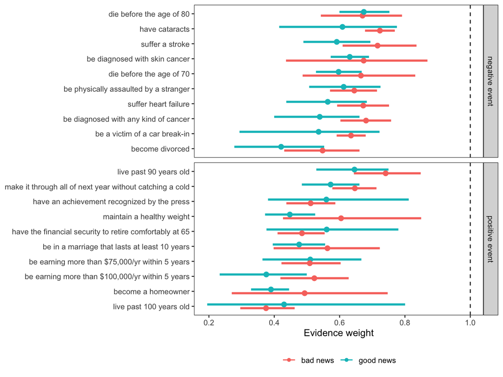

```r
m3_items <- m3 %>%
  spread_draws(b_E, `b_E:g`, r_item[item, term]) %>%
  pivot_wider(names_from = term, values_from = r_item) %>%
  mutate(`bad news` = b_E + E, `good news` = b_E + E + `b_E:g` + `E:g`) %>%
  pivot_longer(c(`bad news`, `good news`), names_to = "news", values_to = "alpha") %>%
  mutate(item = as.character(item)) %>%
  left_join(item_labels, by = "item") %>%
  left_join(distinct(d, item, valence), by = "item")

m3_items %>%
  ggplot(aes(y = reorder(item_text, alpha), x = alpha, color = news)) +
  stat_pointinterval(position = position_dodge(width = .5), .width = .95) +
  geom_vline(xintercept = 1, linetype = "dashed") +
  facet_grid(valence ~ ., scales = "free_y", space = "free_y") +
  labs(x = "Evidence weight", y = NULL, color = NULL) +
  theme_bw() +
  theme(panel.grid = element_blank(), legend.position = "bottom")
```

## M3b: latent regression on LOT-R and age

This replaces the paper’s two-stage correlation of point estimates (Fig. 4) with person covariates inside the model. Participants with missing age are dropped, so M3b is left out of the LOO comparison.

```r
m3b <- fit_brm(
  "m3b_latent_regression",
  control = list(adapt_delta = .95),
  post ~ 0 + E + E:g + E:lotr_z + E:g:lotr_z + E:age_z + E:g:age_z + offset(logit_pre) +
    (0 + E + E:g | subj) + (0 + E + E:g | item),
  data = d, family = Beta(),
  prior = set_prior("normal(0, .5)", class = "b") +
    set_prior("normal(1, .5)", class = "b", coef = "E") +
    set_prior("normal(0, .5)", class = "sd")
)
```

```r
fixef(m3b)
```

```
##               Estimate  Est.Error        Q2.5       Q97.5
## E           0.61029465 0.03629884  0.54187236 0.684447526
## E:g        -0.07037514 0.04419977 -0.16014303 0.015110879
## E:lotr_z   -0.03681010 0.02010603 -0.07714142 0.002526266
## E:age_z    -0.01719344 0.02091183 -0.05678668 0.023839368
## E:g:lotr_z  0.02206191 0.02406617 -0.02519286 0.067097598
## E:g:age_z  -0.04436374 0.02431742 -0.09239076 0.004236300
```

## M4: 2PL on the evidence weight

$\alpha_{ij} = a_j + \lambda_j \theta_i$ with $\theta_i \sim N(0, 1)$ and $\lambda_j = \exp(\log\lambda_j) > 0$ (as in Bürkner, 2021, *JSS*). Items with large $\lambda_j$ separate high and low updaters best. The person $\beta_i$ is correlated with $\theta_i$ through the shared `|p|` ID.

```r
f_2pl <- bf(
  post ~ logit_pre + (a + exp(loglam) * theta + bg * g) * E,
  a ~ 1 + (1 | i | item),
  loglam ~ 1 + (1 | i | item),
  theta ~ 0 + (1 | p | subj),
  bg ~ 1 + (1 | p | subj) + (1 | i | item),
  nl = TRUE
)

m4 <- fit_brm(
  "m4_2pl",
  control = list(adapt_delta = .95),
  f_2pl,
  data = d, family = Beta(),
  prior = set_prior("normal(1, .5)", class = "b", nlpar = "a") +
    set_prior("normal(-1.5, 1)", class = "b", nlpar = "loglam") +
    set_prior("normal(0, .5)", class = "b", nlpar = "bg") +
    set_prior("constant(1)", class = "sd", group = "subj", nlpar = "theta") +
    set_prior("normal(0, .5)", class = "sd", nlpar = "a") +
    set_prior("normal(0, .5)", class = "sd", nlpar = "loglam") +
    set_prior("normal(0, .5)", class = "sd", nlpar = "bg")
)
```

```r
summary(m4)
```

```
##  Family: beta
##   Links: mu = logit
## Formula: post ~ logit_pre + (a + exp(loglam) * theta + bg * g) * E
##          a ~ 1 + (1 | i | item)
##          loglam ~ 1 + (1 | i | item)
##          theta ~ 0 + (1 | p | subj)
##          bg ~ 1 + (1 | p | subj) + (1 | i | item)
##    Data: d (Number of observations: 3720)
##   Draws: 4 chains, each with iter = 2000; warmup = 1000; thin = 1;
##          total post-warmup draws = 4000
##
## Multilevel Hyperparameters:
## ~item (Number of levels: 20)
##                                    Estimate Est.Error l-95% CI u-95% CI Rhat
## sd(a_Intercept)                        0.12      0.03     0.08     0.18 1.00
## sd(loglam_Intercept)                   0.32      0.08     0.20     0.50 1.00
## sd(bg_Intercept)                       0.09      0.05     0.01     0.20 1.00
## cor(a_Intercept,loglam_Intercept)      0.29      0.26    -0.25     0.72 1.00
## cor(a_Intercept,bg_Intercept)         -0.28      0.36    -0.81     0.60 1.00
## cor(loglam_Intercept,bg_Intercept)     0.10      0.38    -0.61     0.81 1.00
##                                    Bulk_ESS Tail_ESS
## sd(a_Intercept)                        1207     2150
## sd(loglam_Intercept)                   1526     2000
## sd(bg_Intercept)                        489      966
## cor(a_Intercept,loglam_Intercept)      1064     1616
## cor(a_Intercept,bg_Intercept)          1110     1387
## cor(loglam_Intercept,bg_Intercept)     1177     1798
##
## ~subj (Number of levels: 186)
##                                   Estimate Est.Error l-95% CI u-95% CI Rhat
## sd(theta_Intercept)                   1.00      0.00     1.00     1.00   NA
## sd(bg_Intercept)                      0.26      0.02     0.22     0.31 1.00
## cor(theta_Intercept,bg_Intercept)    -0.60      0.08    -0.74    -0.42 1.00
##                                   Bulk_ESS Tail_ESS
## sd(theta_Intercept)                     NA       NA
## sd(bg_Intercept)                      1066     1986
## cor(theta_Intercept,bg_Intercept)     1286     2028
##
## Regression Coefficients:
##                  Estimate Est.Error l-95% CI u-95% CI Rhat Bulk_ESS Tail_ESS
## a_Intercept          0.61      0.04     0.54     0.68 1.01      667     1462
## loglam_Intercept    -1.43      0.11    -1.65    -1.22 1.00      900     1664
## bg_Intercept        -0.07      0.04    -0.15     0.01 1.01     1092     1820
##
## Further Distributional Parameters:
##     Estimate Est.Error l-95% CI u-95% CI Rhat Bulk_ESS Tail_ESS
## phi    24.98      0.56    23.90    26.05 1.00     4796     3249
##
## Draws were sampled using sampling(NUTS). For each parameter, Bulk_ESS
## and Tail_ESS are effective sample size measures, and Rhat is the potential
## scale reduction factor on split chains (at convergence, Rhat = 1).
```

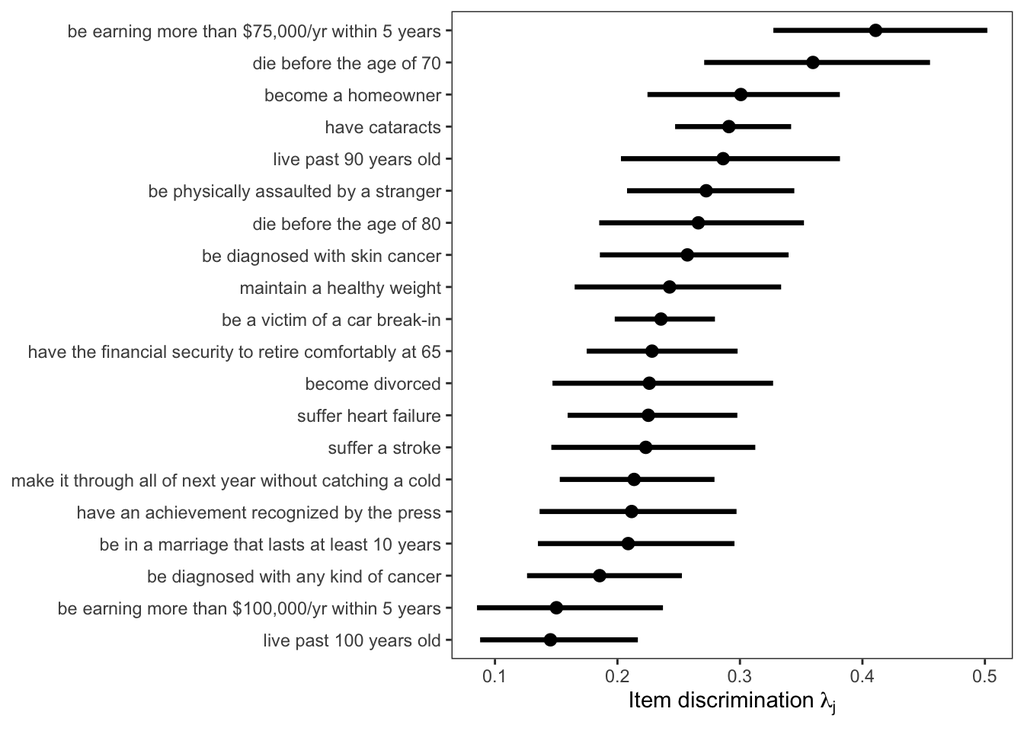

```r
m4 %>%
  spread_draws(b_loglam_Intercept, r_item__loglam[item, ]) %>%
  mutate(lambda = exp(b_loglam_Intercept + r_item__loglam), item = as.character(item)) %>%
  left_join(item_labels, by = "item") %>%
  ggplot(aes(y = reorder(item_text, lambda), x = lambda)) +
  stat_pointinterval(.width = .95) +
  labs(x = expression("Item discrimination" ~ lambda[j]), y = NULL) +
  theme_bw() +
  theme(panel.grid = element_blank())
```

## M5: two-part (hurdle) model

Part 1 is a Bernoulli IRT model for whether the participant changed their estimate at all. (A person-level random slope on `g` in this part was not identified and kept the chains from converging, so it is omitted.) Part 2 is the M3 Beta model, fit only to trials where they did. Person effects are correlated across parts (`|p|`), as are item effects (`|i|`).

```r
f_update <- bf(upd ~ 1 + g + (1 | p | subj) + (1 | i | item), family = bernoulli())
f_size <- bf(
  post | subset(upd_l) ~ 0 + E + E:g + offset(logit_pre) +
    (0 + E + E:g | p | subj) + (0 + E + E:g | i | item),
  family = Beta()
)

m5 <- fit_brm(
  "m5_hurdle",
  f_update + f_size + set_rescor(FALSE),
  data = d,
  prior = set_prior("normal(0, 1.5)", class = "Intercept", resp = "upd") +
    set_prior("normal(0, 1)", class = "b", resp = "upd") +
    set_prior("normal(0, 1)", class = "sd", resp = "upd") +
    set_prior("normal(1, .5)", class = "b", coef = "E", resp = "post") +
    set_prior("normal(0, .5)", class = "b", coef = "E:g", resp = "post") +
    set_prior("normal(0, .5)", class = "sd", resp = "post")
)
```

```r
summary(m5)
```

```
##  Family: MV(bernoulli, beta)
##   Links: mu = logit
##          mu = logit
## Formula: upd ~ 1 + g + (1 | p | subj) + (1 | i | item)
##          post | subset(upd_l) ~ 0 + E + E:g + offset(logit_pre) + (0 + E + E:g | p | subj) + (0 + E + E:g | i | item)
##    Data: d (Number of observations: 3720)
##   Draws: 4 chains, each with iter = 2000; warmup = 1000; thin = 1;
##          total post-warmup draws = 4000
##
## Multilevel Hyperparameters:
## ~item (Number of levels: 20)
##                             Estimate Est.Error l-95% CI u-95% CI Rhat Bulk_ESS
## sd(upd_Intercept)               1.05      0.18     0.75     1.48 1.00      755
## sd(post_E)                      0.12      0.03     0.07     0.18 1.01     1455
## sd(post_E:g)                    0.10      0.05     0.01     0.22 1.01      534
## cor(upd_Intercept,post_E)       0.24      0.24    -0.27     0.67 1.00     1662
## cor(upd_Intercept,post_E:g)     0.29      0.36    -0.45     0.89 1.00     1734
## cor(post_E,post_E:g)           -0.52      0.36    -0.94     0.45 1.00     1328
##                             Tail_ESS
## sd(upd_Intercept)               1627
## sd(post_E)                      2334
## sd(post_E:g)                     600
## cor(upd_Intercept,post_E)       2464
## cor(upd_Intercept,post_E:g)     2008
## cor(post_E,post_E:g)            1399
##
## ~subj (Number of levels: 186)
##                             Estimate Est.Error l-95% CI u-95% CI Rhat Bulk_ESS
## sd(upd_Intercept)               1.29      0.09     1.12     1.47 1.00     1337
## sd(post_E)                      0.21      0.02     0.18     0.24 1.00     1179
## sd(post_E:g)                    0.21      0.03     0.17     0.26 1.00     1400
## cor(upd_Intercept,post_E)       0.18      0.10    -0.03     0.37 1.00      866
## cor(upd_Intercept,post_E:g)     0.14      0.13    -0.13     0.40 1.00     1315
## cor(post_E,post_E:g)           -0.69      0.07    -0.82    -0.53 1.00     1969
##                             Tail_ESS
## sd(upd_Intercept)               2612
## sd(post_E)                      2248
## sd(post_E:g)                    2194
## cor(upd_Intercept,post_E)       1420
## cor(upd_Intercept,post_E:g)     2247
## cor(post_E,post_E:g)            2743
##
## Regression Coefficients:
##               Estimate Est.Error l-95% CI u-95% CI Rhat Bulk_ESS Tail_ESS
## upd_Intercept     0.80      0.26     0.29     1.31 1.01      578      986
## upd_g            -0.18      0.10    -0.38     0.02 1.00     4434     3197
## post_E            0.72      0.04     0.64     0.79 1.00     1257     1856
## post_E:g         -0.08      0.04    -0.17     0.00 1.00     1586     2155
##
## Further Distributional Parameters:
##          Estimate Est.Error l-95% CI u-95% CI Rhat Bulk_ESS Tail_ESS
## phi_post    16.99      0.50    16.00    17.96 1.00     4463     3042
##
## Draws were sampled using sampling(NUTS). For each parameter, Bulk_ESS
## and Tail_ESS are effective sample size measures, and Rhat is the potential
## scale reduction factor on split chains (at convergence, Rhat = 1).
```

Person-level correlations across the two parts:

```r
VarCorr(m5)$subj$cor[, "Estimate", ] %>% round(2)
```

```
##               upd_Intercept post_E post_E:g
## upd_Intercept          1.00   0.18     0.14
## post_E                 0.18   1.00    -0.69
## post_E:g               0.14  -0.69     1.00
```

## M6: free weights on the given and believed base rates

$c_1\,\text{logit}(b) - c_2\,\text{logit}(\tilde b) = c_1 E + (c_1 - c_2)\,\text{logit}(\tilde b)$, so the coefficient on `logit_base` is the asymmetry $c_1 - c_2$. The paper’s model fixes it at 0.

```r
m6 <- fit_brm(
  "m6_free_weights",
  post ~ 0 + E + logit_base + offset(logit_pre) +
    (0 + E + logit_base | subj) + (0 + E | item),
  data = d, family = Beta(),
  prior = set_prior("normal(1, .5)", class = "b", coef = "E") +
    set_prior("normal(0, .5)", class = "b", coef = "logit_base") +
    set_prior("normal(0, .5)", class = "sd")
)
```

```r
fixef(m6)
```

```
##               Estimate  Est.Error        Q2.5       Q97.5
## E           0.53725790 0.02982490  0.47843330  0.59617698
## logit_base -0.05153648 0.01125088 -0.07346426 -0.02977382
```

# Does pessimism survive?

```r
beta_summary <- function(model, par, label) {
  as_draws_df(model) %>%
    pull(!!par) %>%
    mean_qi() %>%
    transmute(model = label, beta = y, lower = ymin, upper = ymax)
}

bind_rows(
  beta_summary(m2, "b_E:g", "M2 person only"),
  beta_summary(m3, "b_E:g", "M3 + items"),
  beta_summary(m4, "b_bg_Intercept", "M4 2PL"),
  beta_summary(m5, "b_post_E:g", "M5 size | changed")
) %>%
  knitr::kable(digits = 3)
```

| model | beta | lower | upper |
| --- | --- | --- | --- |
| M2 person only | -0.094 | -0.139 | -0.050 |
| M3 + items | -0.067 | -0.149 | 0.018 |
| M4 2PL | -0.072 | -0.152 | 0.006 |
| M5 size \| changed | -0.083 | -0.171 | 0.004 |

# Model comparison

LOO on the models fit to the same observations (M3b drops missing ages; M5 has a different likelihood).

```r
# add_criterion re-saves each fit to its cache file, so LOO is computed once
comparable <- list(M0 = m0, M1 = m1, M2 = m2, M3 = m3, M4 = m4, M6 = m6) %>%
  map(add_criterion, criterion = "loo")
loo_compare(map(comparable, ~ .x$criteria$loo))
```

```
##  model elpd_diff se_diff p_worse diag_diff       diag_elpd
##     M4       0.0     0.0      NA           88 k_psis > 0.7
##     M3      -4.6    17.1    0.61           82 k_psis > 0.7
##     M6     -20.9    36.7    0.72           48 k_psis > 0.7
##     M2    -108.8    27.1    1.00           71 k_psis > 0.7
##     M1    -172.3    41.6    1.00           33 k_psis > 0.7
##     M0   -2017.7   144.4    1.00
```

Many observations have Pareto $k > 0.7$, so these PSIS-LOO estimates are unreliable. PSIS-LOO also asks how well a model predicts a held-out *trial* from a participant it has already seen.

## Grouped K-fold CV

Ten folds split by participant, identical for every model. Each held-out participant gets a new random effect drawn from the fitted population distribution (`sample_new_levels = "gaussian"`), and their 20 trials are scored jointly (`joint = "group"`). The ELPD is therefore summed over 186 participants and measures how well each model predicts a new person. M0 is omitted: it has no participant-level parameters, and it trails the other models by about 2000 ELPD in PSIS-LOO.

```r
library(future)
options(future.globals.maxSize = 4 * 1024^3)
plan(multisession, workers = 3)  # 3 folds at a time x 4 chains each

set.seed(2022)
fold_ids <- loo::kfold_split_grouped(K = 10, x = d$subj)

# cached per model; delete kfold_<model>.rds after changing that model
run_kfold <- function(model, name) {
  path <- file.path(fit_dir, paste0("kfold_", name, ".rds"))
  if (file.exists(path)) return(readRDS(path))
  kf <- kfold(model, folds = fold_ids, group = "subj", joint = "group",
              sample_new_levels = "gaussian", cores = 4)
  saveRDS(kf, path)
  kf
}

# M0 has no participant parameters (and no grouping factor for joint scoring)
kfolds <- imap(comparable[names(comparable) != "M0"], run_kfold)
plan(sequential)
loo_compare(kfolds)
```

```
##  model elpd_diff se_diff p_worse diag_diff diag_elpd
##     M3       0.0     0.0      NA
##     M4      -6.5    12.0    0.71
##     M6     -34.1    26.9    0.90
##     M2     -77.2    25.2    1.00
##     M1    -165.5    39.3    1.00
```

# Convergence diagnostics

```r
list(M0 = m0, M1 = m1, M2 = m2, M3 = m3, M3b = m3b, M4 = m4, M5 = m5, M6 = m6) %>%
  imap_dfr(~ tibble(
    model = .y,
    max_rhat = max(rhat(.x), na.rm = TRUE),
    min_ess_ratio = min(neff_ratio(.x), na.rm = TRUE),
    divergent = sum(subset(nuts_params(.x), Parameter == "divergent__")$Value)
  )) %>%
  knitr::kable(digits = 3)
```

| model | max_rhat | min_ess_ratio | divergent |
| --- | --- | --- | --- |
| M0 | 1.001 | 0.391 | 0 |
| M1 | 1.006 | 0.182 | 0 |
| M2 | 1.007 | 0.139 | 0 |
| M3 | 1.010 | 0.149 | 0 |
| M3b | 1.013 | 0.091 | 0 |
| M4 | 1.008 | 0.122 | 0 |
| M5 | 1.014 | 0.133 | 0 |
| M6 | 1.005 | 0.223 | 0 |

# Earlier draft model (superseded)

Kept for reference. It codes good news as `item_prob > pre`, which ignores event valence and the participant’s own base-rate estimate (the Sharot et al. coding the paper argues against). It also models the level of the posterior rather than the update, with a Gaussian likelihood on a bounded response.

```r
df_long <- df %>%
  gather(key = "phase", value = "estimate", baserate, pre, post) %>%
  filter(phase == "post") %>%
  mutate(good_news = ifelse(item_prob > pre, 1, 0))

fit_cr_irt <- brm(
  bf(estimate ~ 1 + (1 | item_num) + (1 | subj_id) + good_news),
  data = df_long,
  family = gaussian(),
  chains = 4,
  cores = 4
)
```